# Plantilla básica para ioslides

Diciembre de 2020

## Slide “especial” (en negro)

## Slide con bullets incrementales

- La fuente de esta slide será **small**
- Los bullets aparecerán **incrementalmente**, de uno en uno.

## Otra slide con fuente pequeña pero bullets aparecen todos a la vez

- Se pueden crear slides con 3 marcas: `#`, con `##` y con `-----`
- Con `#` se crea un slide especial (en negro), que puede servir para separar secciones
- Con `##` se crean slides “normales” (en blanco)
- Con `------` se crean slides en blanco, pero **sin título**

## Slide con una imagen y texto

- Un poco de texto y abajo una imagen

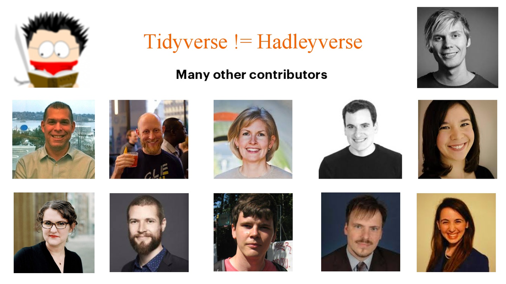

- Otro bullet con texto.
- Como he usado `------` se crea una slide **sin título**
- Abajo otra imagen

[figure not shown]

## Slide con indentation

- Para poner bullets “anidados” tienes que usar el tabulador: 2 tabuladores o 4 espacios.
  - anidado 1
  - anidado 2
- Volvemos al nivel superior

## slide especial ( se ve en negro )

## Otra slide “normal” con `##`

- Un enlace: para más información sobre `ioslides`, ve [aquí](https://rmarkdown.rstudio.com/ioslides_presentation_format.html)

## **R-base vs. [tidyverse](https://www.tidyverse.org/)**

#### Esto es un poco forzar las cosas, pero … funciona

- “Programs must be written for people to read, and only incidentally for machines to execute” — Hal Abelson
- “If I had one thing to tell biologists learning bioinformatics, it would be write **code for humans**, write **data for computers**” — Vince Buffalo
- “An important aspect of writing data for computers is to **make your data TIDY**” — Jenny Bryan
- Lo siguiente es un chunk, en realidad no, porque le faltan las llaves `{}`, pero si verá de forma especial

```r
data %>% filter(X1 > 400) %>% group_by(X2) %>% summarise(media = mean(X3))
```

Esto sí son chunks. Se ejecutarán los 2. El primero no se verá (`echo = FALSE`)

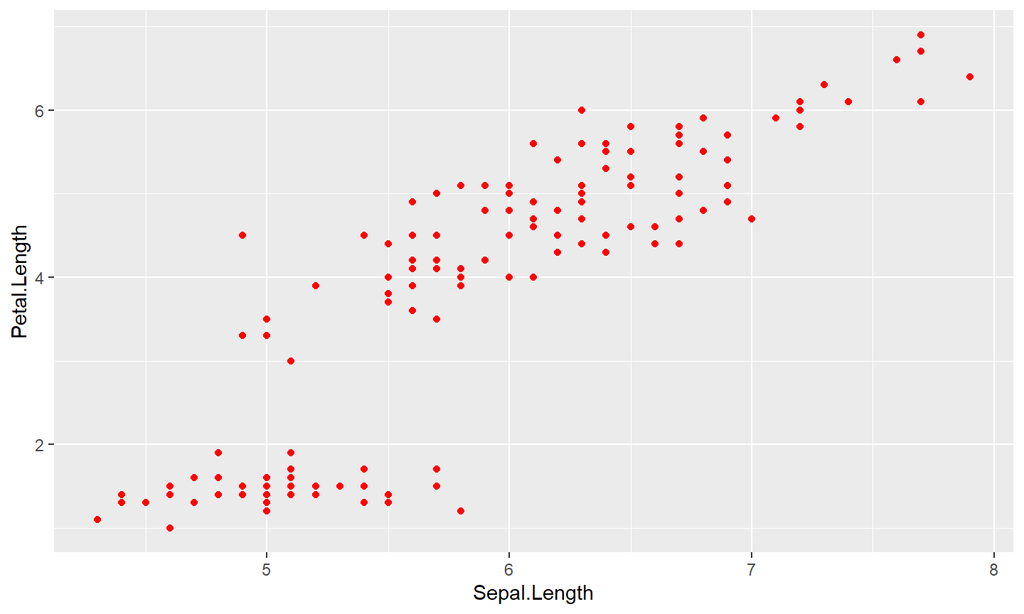

```r
ggplot(iris, aes(x = Sepal.Length, y = Petal.Length)) +
  geom_point(color = "red")
```

## Bibliografía.

En realidad son algunos links por si os ayudan a hacer vuestras `ioslides`

- En el libro [R Markdown: The Definitive Guide](https://bookdown.org/yihui/rmarkdown/) hay un capítulo dedicado a las `ioslides`, concretamente [aquí](https://rmarkdown.rstudio.com/ioslides_presentation_format.html). El repo con el código fuente del libro está [aquí](https://github.com/rstudio/rmarkdown-book) y el del capítulo 4 sobre presentaciones [aquí](https://github.com/rstudio/rmarkdown-book/blob/master/04-presentations.Rmd)
- [Presentation with ioslides](https://garrettgman.github.io/rmarkdown/ioslides_presentation_format.html)
- [Tutorial sobre Rmd](https://codingclubuc3m.rbind.io/post/2019-09-24/) con una pequeña sección sobre `ioslides`.
- Un [ejemplo de *ioslides*](https://choux130.github.io/slide_thesis_ioslides/#1). El código está [aquí](https://github.com/choux130/slide_thesis_ioslides).

Dos links más que igual os resultan complicados:

- https://www.rdocumentation.org/packages/rmarkdown/versions/1.10/topics/ioslides_presentation
- https://stackoverflow.com/questions/50258283/how-to-enable-syntax-highlighting-in-code-chunks-within-r-markdown-ioslides-pres

## Mucha suerte con las slides, 😄 !!!